# **Addition Insights - Companies to Watch Newsletter**

December 1, 2022

## **Doccla**

**Company:** Doccla  
**Country (Operating):** London, England, United Kingdom  
**Founded Date:** January 01, 2017  
**Homepage:** https://www.doccla.com  
**Current Headcount:** 31  
**Lifetime Funding:** $19,526,641  
**Number of Funding Rounds:** 3  
**Investors:** KHP MedTech Innovations, Giant Ventures, KHP Ventures, General Catalyst, Speedinvest  
**Most Recent Funding:** SERIES A - September 29, 2022  
**Sectors:** Health / Wellness, IoT, Financial Technology, Health / Nutritional Science  
**Description:** We are changing healthcare for the people who need it the most. Want to join? Doccla is changing healthcare by building a virtual hospital ward. We partner with caregivers to take patients out from hospitals and monitor them remotely using medical class IoT devices. Email us at hello@doccla.com if you want to know more.

### **Headcount**

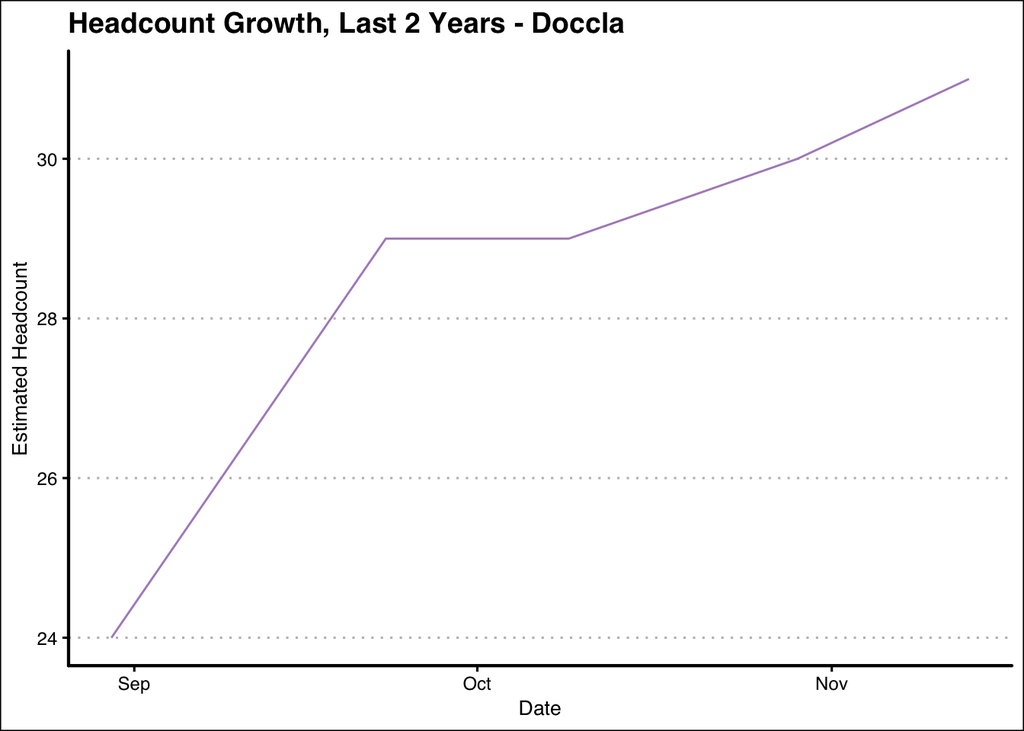

## **Baseten**

**Company:** Baseten  
**Country (Operating):** 575 Sutter Street, Suite 201, San Francisco, CA 94102, United States  
**Founded Date:** January 01, 2019  
**Homepage:** https://baseten.co  
**Current Headcount:** 24  
**Lifetime Funding:** $20,000,000  
**Number of Funding Rounds:** 2  
**Investors:** Greg Brockman, DJ Patil, Pascal Levy-Garboua, Ascolta Ventures, LLC , Jay Simons, Lachy Groom, NULL, Greylock, Dylan Field, Caffeinated Capital, Sandy Kory, South Park Commons, base case capital, Scott Belsky, AI Fund, Dev Ittycheria, Jean-Denis Greze, Mustafa Suleyman  
**Most Recent Funding:** SERIES A - April 26, 2022  
**Sectors:** Organization Management, AI / ML, Data Analytics, Health / Wellness, Financial Technology, Dev Tools  
**Description:** Baseten makes going from machine learning models to production-grade applications fast and easy. With Baseten, data science and machine learning teams can ship full-stack ML applications without backend, frontend or MLOps knowledge, enabling faster, smarter decision-making at their organizations.

### **Headcount**

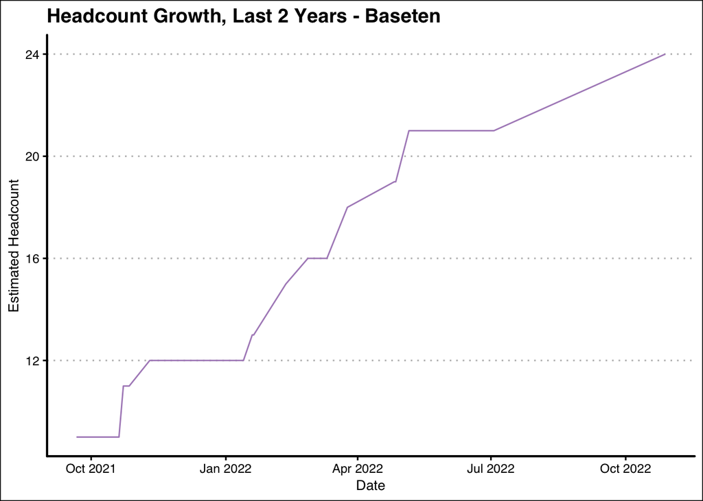

## **AcuityMD, Inc.**

**Company:** AcuityMD, Inc.  
**Country (Operating):** 16192 Coastal Highway, Lewes, DE 19958, United States  
**Founded Date:** January 01, 2018  
**Homepage:** https://acuitymd.com  
**Current Headcount:** 54  
**Lifetime Funding:** $31,000,000  
**Number of Funding Rounds:** 4  
**Investors:** Artisanal Ventures, Ajax Health, Redpoint Ventures, Benchmark , Investment Group of Santa Barbara, Spearhead  
**Most Recent Funding:** SERIES A - May 12, 2022  
**Sectors:** Health / Wellness, Medical Devices, Financial Technology, Biotechnology, Chemical / Life Sciences  
**Description:** We are a fully remote, venture-backed technology company that connects software and data to help MedTech companies of all sizes transform how they bring products to market. 🔎 We bring acuity to medical markets. AcuityMD creates software as meticulously crafted as the highly specialized MedTech products that save lives each day. From Day 1 we’ve worked closely with leading MedTech innovators, from field-based commercial teams at the largest enterprises to entrepreneurs launching new products. We built our platform to give these users ‘acuity’- the ability to understand their markets easily and instantly. Some of our current solutions include: 🎯 Targeting - Identify and prioritize doctors to train on the latest innovations 💰 Pipeline & Forecasting - Quantify and execute on opportunities to expand technology adoption 🔗 Data Platform - Integrate data to track product adoption and predict demand We’re just getting started on our mission - join us.

### **Headcount**

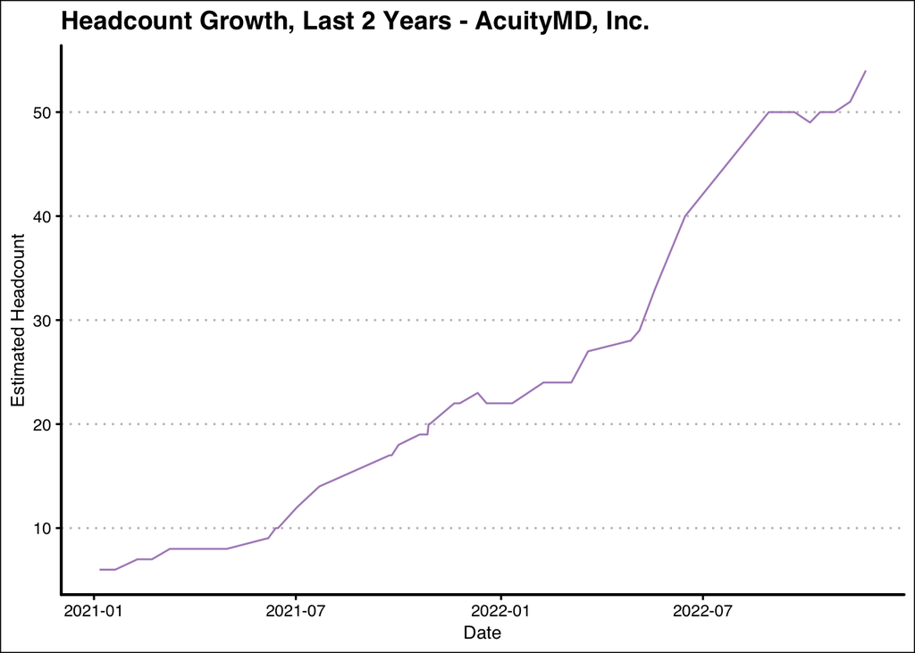

## **RxDefine**

**Company:** RxDefine  
**Country (Operating):** 200 South Biscayne Boulevard, Suite 20floor, Miami, FL 33131, United States  
**Founded Date:** January 01, 2018  
**Homepage:** https://rxdefine.com  
**Current Headcount:** 58  
**Lifetime Funding:** $5,200,000  
**Number of Funding Rounds:** 2  
**Investors:** Susa Ventures, Trust Ventures, Founders Fund, RRE Ventures, Byers Capital, Caffeinated Capital, mark vc, Bling Capital, Greycroft  
**Most Recent Funding:** SERIES B - April 15, 2022  
**Sectors:** Financial Technology, Health / Wellness, Consumer Software Services, SaaS  
**Description:** Here at RxDefine we ethically empower people to navigate their health. We believe that every human should have low cost, transparent access to the information, products, and services they need to take full ownership of their health. We are looking for like-minded people eager to join our team and to help architect the future of life science commercialization through our enterprise SaaS products. We are a small but mighty team of around 60 (for now!) internationally-based colleagues. As we grow, we are looking for Definers who want to join us on our growth journey and who are ALSO committed to our values of teamwork and honesty! Our founding team has designed and built companies on the consumer front acquired by Google, as well as enterprise tech companies deployed across The Fortune 500. We are backed by some of the best investors in the world, including RRE Ventures, Bling Capital, Founders Fund, Greycroft, and more.

### **Headcount**

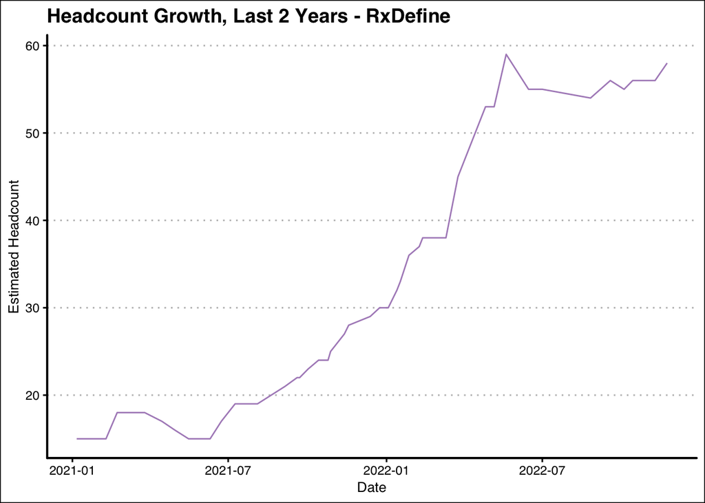

## **Gaia**

**Company:** Gaia  
**Country (Operating):** London, England, United Kingdom  
**Founded Date:** January 01, 2019  
**Homepage:** https://gaiafamily.com  
**Current Headcount:** 68  
**Lifetime Funding:** $23,000,000  
**Number of Funding Rounds:** 2  
**Investors:** Kindred Capital VC, Seedcamp, Optum Ventures, L Marks, Serge Chiaramonte, Clocktower Technology Ventures, Atomico  
**Most Recent Funding:** SERIES A - February 14, 2022  
**Sectors:** Financial Technology, Financial / Insurance Services, Health / Wellness, Travel / Lifestyle / Leisure  
**Description:** Gaia is the world’s first IVF insurance, remaking how we make families. We help you plan, pay for and protect your IVF journey, making IVF more accessible for more people. Because everyone who wants a family should have the chance to try.

### **Headcount**

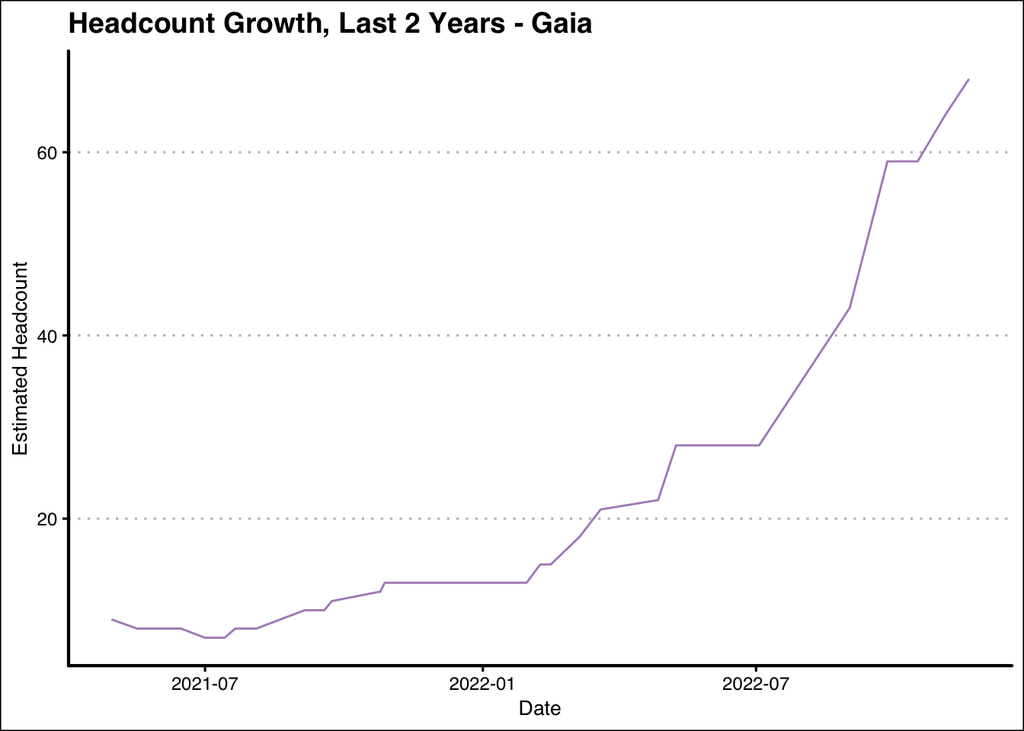

## **Sprinter Health**

**Company:** Sprinter Health  
**Country (Operating):** San Francisco, California 94114, US  
**Founded Date:** January 01, 2021  
**Homepage:** http://pulsetera.com  
**Current Headcount:** 50  
**Lifetime Funding:** $0  
**Number of Funding Rounds:**  
**Investors:** Andreessen Horowitz, GV (Google Ventures), Accel, General Catalyst, Formic Ventures, Empowered Systems  
**Most Recent Funding:** - N/A  
**Sectors:** Financial Technology, Health / Wellness, Health / Nutritional Science  
**Description:** At Sprinter Health, we’re focused on dramatically expanding access to healthcare by reimagining the patient experience—delivered at home and powered by technology for scale. We’re a boots-on-the-ground clinician network for the telehealth age, bringing routine blood draws, labs, and vitals checks into people’s busy lives.

### **Headcount**

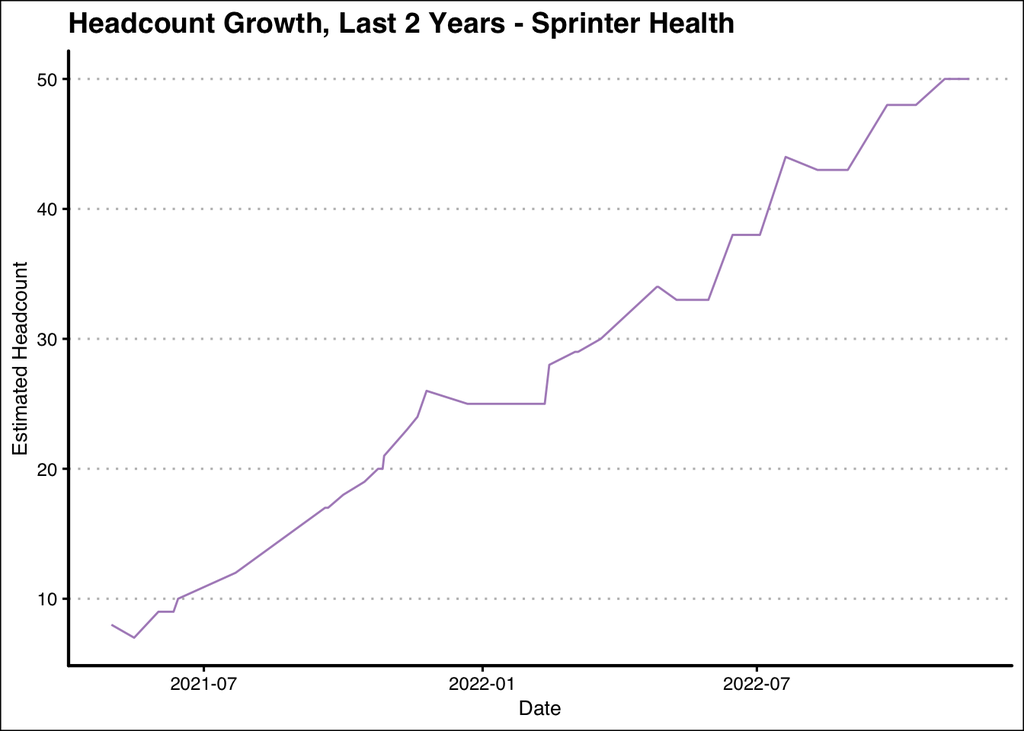

## **Island**

**Company:** Island  
**Country (Operating):** Dallas, TX, United States  
**Founded Date:** January 01, 2020  
**Homepage:** https://island.io  
**Current Headcount:** 150  
**Lifetime Funding:** $260,890,000  
**Number of Funding Rounds:** 4  
**Investors:** Joe Sexton, Insight Partners, Cerca Partners, Rakesh Loonkar, Georgian, Cyberstarts, Sequoia Capital, Michael Boodaei, Stripes , SVCI - Silicon Valley CISO Investments, Cisco Investments  
**Most Recent Funding:** SERIES B - November 10, 2022  
**Sectors:** Transportation / Mobility, Future of Work, Productivity / Collaboration, Logistics / Supply Chain, Cybersecurity  
**Description:** What if the enterprise had complete control over the browser? What would it mean for security, for productivity, for work itself? Introducing Island, the Enterprise Browser - the ideal enterprise workplace, where work flows freely while remaining fundamentally secure. With the core needs of the enterprise naturally embedded in the browser itself, Island gives organizations complete control, visibility, and governance over the last mile, while delivering the same smooth Chromium-based browser experience users expect. Led by experienced leaders in enterprise security and browser technology and backed by leading venture funds – Insight Partners, Sequoia Capital, Cyberstarts and Stripes Capital – Island is redefining the future of work for some of the largest, most respected enterprises in the world. Welcome to work as it should be. www.island.io

### **Headcount**

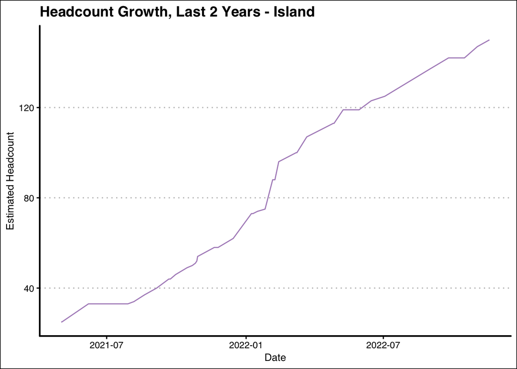

## **Cerby**

**Company:** Cerby  
**Country (Operating):** 1272 Caroline Street, Alameda, CA 94501, United States  
**Founded Date:** January 01, 2020  
**Homepage:** http://cerby.com  
**Current Headcount:** 61  
**Lifetime Funding:** $15,500,000  
**Number of Funding Rounds:** 3  
**Investors:** Salesforce Ventures, Gokul Rajaram, Ridge Ventures, Okta, Crew Capital, Xoogler.co, AV8 Ventures, The Carnrite Group, Bowery Capital, Vela Partners, Global Founders Capital, Xochi Ventures, Incubate Fund, Okta Ventures, A.Capital Ventures, CoreAngels, Founders Fund, ACapital Beteiligungsberatung, Eduardo Gutierrez Talledo  
**Most Recent Funding:** SEED - June 28, 2022  
**Sectors:** Productivity / Collaboration, Security / Encryption Tech, Cybersecurity  
**Description:** Cerby delivers the world’s first user-driven security platform for unmanageable applications. We protect brands around the world, including some of the most recognizable businesses, by automating manual processes, uncovering security issues, and empowering users to implement zero trust principles. Our technology uses robotic process automation to understand applications in a business context and automatically enforces security best practices before misconfigurations turn into breaches. Cerby is a must-have for technology executives and their teams to protect the brand, be secure and increase productivity. At Cerby, we believe that employee application choice and security can go hand-in-hand, but only when employees are trusted to choose the best applications for their work. When employees are allowed this choice, productivity increases and security moves from the IT department to the responsibility of every employee. Since we released our platform in 2021, Cerby’s software lets clients like L’Oreal, Wizeline and MiSalud fix common application liabilities efficiently while facilitating collaboration. To learn more about Cerby, visit www.cerby.com and to join our team, visit www.cerby.com/about-us/careers

### **Headcount**

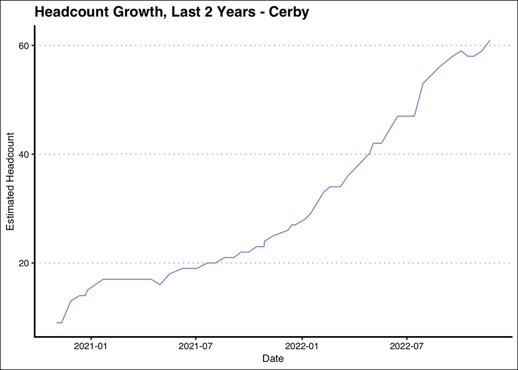